# Coursework Report

[output not shown]

[output not shown]

[interactive chart not shown]

[figure not shown]

[interactive chart not shown]

# Coursework Report

Analysing Data, Spring 2020

# Methods

## Participants

This study originally used the data of 395 participants, however 27 were removed for being under the ethical age. This resulted in the data of 368 participants being used. The mean age of participants used was 21, with a standard deviation of 1.89 (refer to Figure 1). Figure 2 shows descriptive statistics of the participants in greater detail.

Figure 1: Descriptive statistics of participant ages.

| N | Mean Age | Standard Deviation |
| --- | --- | --- |
| 368 | 21.35 | 1.89 |

Figure 2: Descriptive statistics of participant ages by condition and gender.

| Gender | Condition | N | Mean Age | Standard Deviation |
| --- | --- | --- | --- | --- |
| female | control | 71 | 21.54 | 1.89 |
| female | experimental | 105 | 21.14 | 1.89 |
| male | control | 78 | 21.31 | 1.89 |
| male | experimental | 54 | 21.06 | 1.89 |
| other | control | 24 | 21.50 | 1.89 |
| other | experimental | 36 | 22.00 | 1.89 |

## Design

# Results

It was predicted that the green choice of two generally cheaper products would be selected by participants and that with the most expensive product, the car, the more luxurious alternative would be chosen when given status motive. As seen in Figure 3, both the experimental and control groups chose the non-green, luxurious car (58.4% in the experimental and 58.6% in the control).

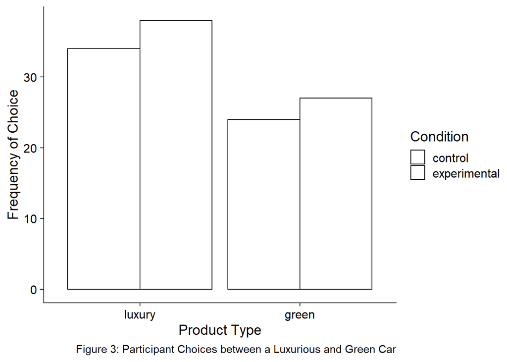

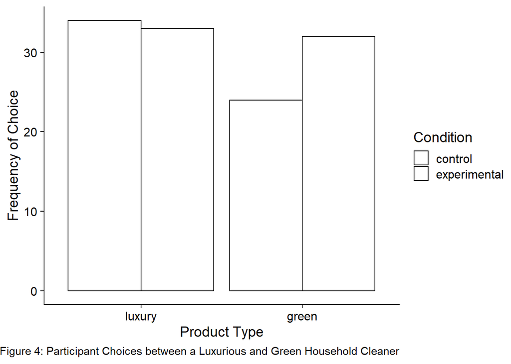

Figure 5 shows that the control group chose the luxurious dishwasher more frequently than the green dishwasher (59.6% chose the luxurious dishwasher). However, the experimental group picked the green dishwasher on more occasions (50.8% chose the green dishwasher.).

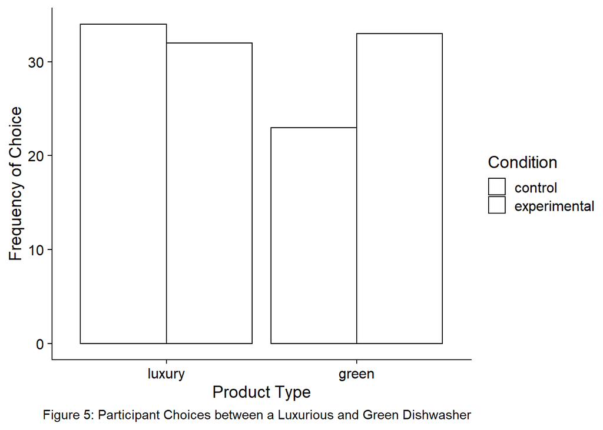

# Discussion

A related study, conducted by Hartmann and Apaolaza-Ibanez (2012), found that brand and purchase attitudes changed in individuals when given green, environmentally friendly alternatives. This study supports the findings of the current study. There are many studies that further explore that pro-environmental alternatives have on purchase habits and attitudes, finding that with status motive, individuals are generally more inclined to purchase green products (Steg, Bolderdijk, Keizer, Perlaviciute, 2014)

This study has its own strengths and limitations. One strength of the research is that it uses quantitative measures. This is a strength as it leads to high reliability and the data is extremely precise, allowing for in-depth analysis. However, the use of quantitative data may also present as a limitation. Quantitative data has difficulties explaining complex issues that have multiple impacting factors. It could be argued that the topic of status and its impact on the purchase of green products is a more complex matter that requires detailed data in order to be understood fully. To rectify this, further studies could use qualitative methods, such as self-reports, alongside quantitative methods in order to provide a deeper narrative into the way in which status may impact purchase attitudes.

Based on the results from this study and previously conducted studies, however, it would be reasonable to state that there is a relationship between status and the purchase of green products. This is because there is a large amount of research that supports this view. However, there may be a limit to which status can impact purchase attitudes, as this study found that even when given status motive, participants would not choose the green car more frequently, instead opting to choose the luxurious option. This could be due to the fact that items such as cars tend to be more important to people and goal orientated. Therefore, people may be seen prioritising ‘dream cars’ over economical and environmental options.

This line of research is becoming increasingly important. This is due to the rising rate of need to be environmentally friendly due to the global climate. This topic of research may discover more impactful methods to change purchase attitudes to be greener. There is already a great amount of research into advertising and factors that contribute to consumer choices in the purchase of green products (Maniatis, 2016, Hu, Hu, Parsa, 2017). The need for green purchase is likely to only increase in future, making this area of research a pressing matter.

# References

Griskevicius, V., Tybur, J., & Bergh, B. V. D. (2010). Going Green to Be Seen: Status, Reputation, and Conspicuous Conservation. PsycEXTRA Dataset. doi: 10.1037/e621072012-217

Hartmann, P., & Apaolaza-Ibáñez, V. (2012). Consumer attitude and purchase intention toward green energy brands: The roles of psychological benefits and environmental concern. Journal of Business Research, 65(9), 1254–1263. doi: 10.1016/j.jbusres.2011.11.001

Hu, H.-H., Hu, H.-Y., & Parsa, H. (2017). Ambivalence Attitudes Toward Green Products and the Moderating Role of Green Advertisement: An Extended Abstract. Marketing at the Confluence between Entertainment and Analytics Developments in Marketing Science: Proceedings of the Academy of Marketing Science, 1289–1294. doi: 10.1007/978-3-319-47331-4_252

Maniatis, P. (2016). Investigating factors influencing consumer decision-making while choosing green products. Journal of Cleaner Production, 132, 215–228. doi: 10.1016/j.jclepro.2015.02.067

Steg, L., Bolderdijk, J. W., Keizer, K., & Perlaviciute, G. (2014). An Integrated Framework for Encouraging Pro-environmental Behaviour: The role of values, situational factors and goals. Journal of Environmental Psychology, 38, 104–115. doi: 10.1016/j.jenvp.2014.01.002